# Assignment 4/5

Withee Poositasai

2022-10-27

# Percentage of electricity generated from renewable energy sources in Estonia (1999-2020)

## 1. Data and expectation

I’m interesting in Estonia’s renewable energy generation from this dataset: https://andmed.stat.ee/en/stat/majandus__energeetika__energia-tehususe-naitajad/KE36

My questions are

1. What is the average percentage of electricity generated from renewable energy from 1999-2020?
2. What is the year with the less percentage of electricity generated from renewable energy?
3. What is the year with the most percentage of electricity generated from renewable energy?
4. What is the distribution of electricity generated from renewable energy percentage from 1999-2020?
5. What is the trend of electricity generated from renewable energy, that likely to happen, after 2020?

## 2. Import data into R

I downloaded the csv data and import it into R as a tibble.

```r
rawData <- read_csv("KE36_20221019-135752.csv", show_col_types = FALSE)
rawData
```

```
## # A tibble: 1 × 24
##   Indica…¹ `1999` `2000` `2001` `2002` `2003` `2004` `2005` `2006` `2007` `2008`
##   <chr>     <dbl>  <dbl>  <dbl>  <dbl>  <dbl>  <dbl>  <dbl>  <dbl>  <dbl>  <dbl>
## 1 Electri…      0    0.1    0.1    0.5    0.6    0.5    1.1    1.4    1.4      2
## # … with 13 more variables: `2009` <dbl>, `2010` <dbl>, `2011` <dbl>,
## #   `2012` <dbl>, `2013` <dbl>, `2014` <dbl>, `2015` <dbl>, `2016` <dbl>,
## #   `2017` <dbl>, `2018` <dbl>, `2019` <dbl>, `2020` <dbl>, `2021` <chr>, and
## #   abbreviated variable name ¹Indicator
```

## 3. Cleaning and reshaping data

Raw data is not easy to use. I want to transpose the table, swapping row and column and clean up unused data. I will remove indicator column because we only have one indicator which is the *Electricity generated from renewable energy sources*.

I treat `year` as a numerical step data since the range between each year can be treat as equal. It’s also allow us to plot a line chart to see changes in each year.

I treat `percentage` as continues numerical data because it can range between 0-100 with any decimal points.

```r
cleanedData <- as_tibble(cbind(names(rawData), t(rawData)))   # Transpose table
colnames(cleanedData) <- c('year', 'percentage')              # Rename column
cleanedData <- cleanedData[2:23,]                             # Remove first and last column
cleanedData$year <- as.integer(cleanedData$year)              # Change year type to integer
cleanedData$percentage <- as.double(cleanedData$percentage)   # Change percentage type to double

cleanedData
```

```
## # A tibble: 22 × 2
##     year percentage
##    <int>      <dbl>
##  1  1999        0
##  2  2000        0.1
##  3  2001        0.1
##  4  2002        0.5
##  5  2003        0.6
##  6  2004        0.5
##  7  2005        1.1
##  8  2006        1.4
##  9  2007        1.4
## 10  2008        2
## # … with 12 more rows
```

## 4. Statistical values analysis

### 4.1 Central tendency

First, I want to find mean and median of the percentage. Mode is not that useful since percentage is a continues data.

```r
mean(cleanedData$percentage)
```

```
## [1] 8.954545
```

```r
median(cleanedData$percentage)
```

```
## [1] 8.15
```

- `Q1` Average percentage of renewable energy generation from 1999-2020 is *8.95%*

### 4.2 Min and Max

Next I want to get a row with min and max percentage.

```r
cleanedData[cleanedData$percentage == min(cleanedData$percentage),] # Record with min percentage
```

```
## # A tibble: 1 × 2
##    year percentage
##   <int>      <dbl>
## 1  1999          0
```

```r
cleanedData[cleanedData$percentage == max(cleanedData$percentage),] # Record with max percentage
```

```
## # A tibble: 1 × 2
##    year percentage
##   <int>      <dbl>
## 1  2020       28.3
```

- `Q2` Estonia generate **the less** percentage of renewable energy generation in *1999* with value of *0%*
- `Q3` Estonia generate **the most** percentage of renewable energy generation in *2020* with value of *28.3%*

### 4.3 Standard deviation

```r
sd(cleanedData$percentage)
```

```
## [1] 8.713685
```

## 5. Visualization

### 5.1 Histogram

Next, I plot a histogram percentage to see the distribution.

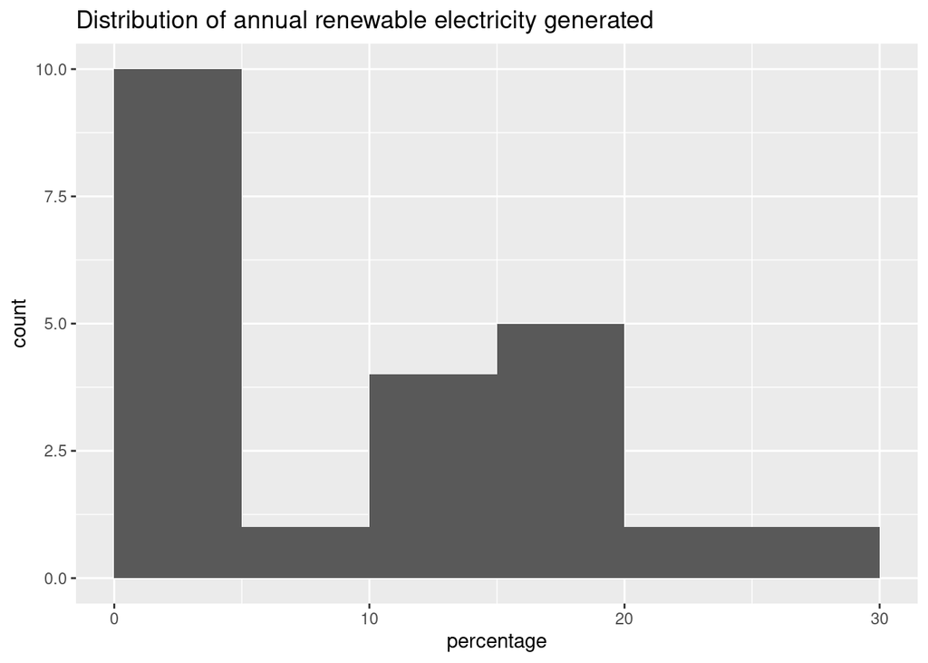

```r
ggplot(cleanedData, aes(x=percentage)) +
  geom_histogram(binwidth = 5, boundary = 0) +
  ggtitle("Distribution of annual renewable electricity generated")
```

- `Q4` From the histogram we can see that most of the years (10 out of 22) Estonia only produce electricity from renewable energy less than 5%. While only 2 years can produce 20% or more. These data make the distribution skewed a lot into the right.

### 5.2 Line chart

Finally, I plot a line chart which allow us to easily see the changes in each year and the trend for the future.

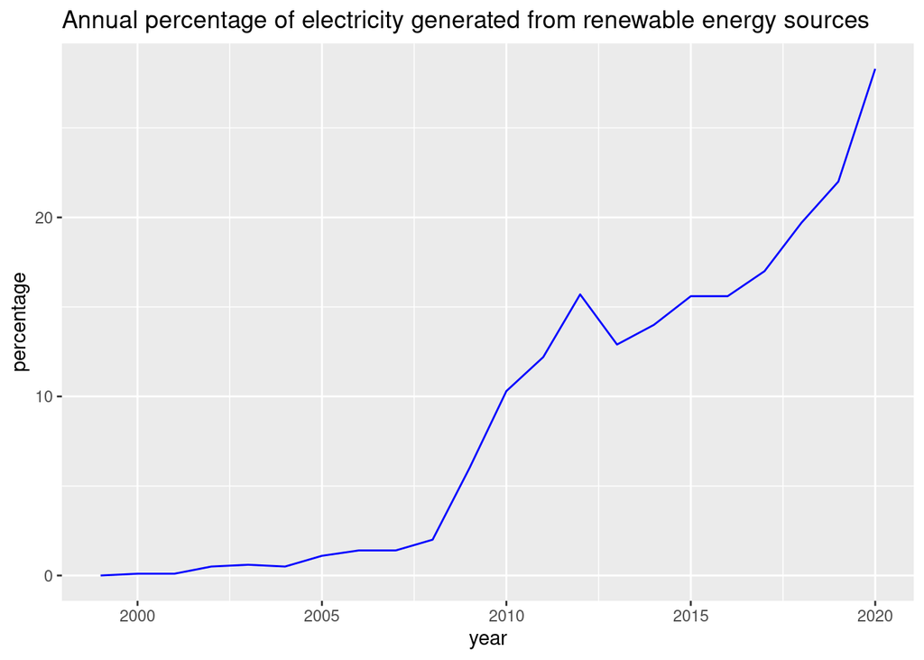

```r
ggplot(cleanedData, aes(x=year, y=percentage)) +
  geom_line(color='blue') +
  ggtitle("Annual percentage of electricity generated from renewable energy sources")
```

- `Q5` From the line chart, we can see the trend that the proportion of electricity generated from renewable energy **are likely to increase** in the future.

# 6. Conclusion and refining questions

Percentage of electricity generated from renewable energy in Estonia is increasing, which is a good sign for both people and environment. But alone this percentage is not enough, answering the following questions should allow us to see the bigget picture.

1. What is the total Kw/h of electricity that Estonia generated in each year?
2. What are the proportion of other source?
3. What is the Estonian energy consumption in each year?